# STA426 Exercise Week 13

## Segmentation example

Here, we make a toy example of some data with changepoints, in order to play around with the circular binary segmentation method. Here is a short pipeline:

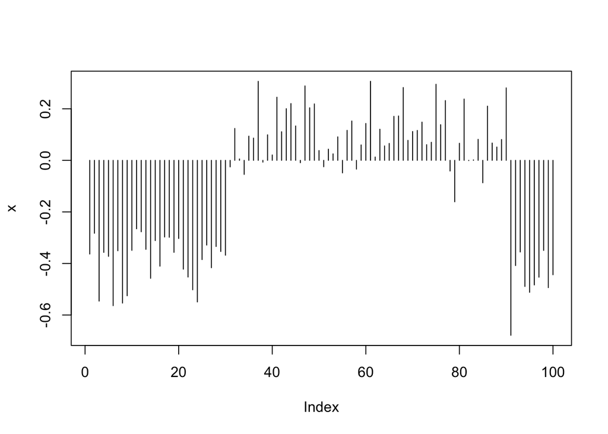

```r
n <- 100
x <- rnorm(n, sd=0.1) + rep(c(-0.4,0.1,-0.4), c(30,60,10))
plot(x, pch=19, type="h")
```

```r
# run segmented
library("DNAcopy")
test1 <- segment(CNA(x, rep("chr1",n), 1:n))
```

```
## Analyzing: Sample.1
```

```r
test1$output
```

```
##         ID chrom loc.start loc.end num.mark seg.mean
## 1 Sample.1  chr1         1      30       30  -0.3900
## 2 Sample.1  chr1        31      90       60   0.1008
## 3 Sample.1  chr1        91     100       10  -0.4668
```

### Exercise 1a. Understand the output of the segment() function and overlay the segmentation (here, three segments) onto the plot.

### Exercise 1b (optional). Calculate all partial sums and the Olshen *et al.* (2004) statistic for all *pairs* of differences. Where is this statistic maximized? Is this indicative of the “true” differences in segments?

## Peak finding example

Below is a pipeline using BayesPeak, starting from much-reduced BED files (the BED files stores the location of mapped reads reads for a H3K4me3 chromatin immunoprecipitation – or ChIP – pulldown as well as an Input).

```r
library(GenomicRanges)
library(BayesPeak)
```

```r
ipf <- "H3K4me3reduced.bed.gz"
inf <- "Inputreduced.bed.gz"

bp <- bayespeak(ipf, inf, chr = "chr16", start = 9.2E7, end = 9.5E7,
                iterations = 2000L, use.multicore = TRUE)
```

```
##
## [0% done] Starting chr16:9.2e+07-9.5e+07:
```

```
## ..
```

```
## Done.
```

```r
bpo <- summarize.peaks(bp)
bpo
```

```
## RangedData with 47 rows and 1 value column across 1 space
##        space            ranges   |                PP
##     <factor>         <IRanges>   |         <numeric>
## 1      chr16 92057850-92059600   |                 1
## 2      chr16 92158500-92159150   | 0.999999999994774
## 3      chr16 92300850-92302350   |                 1
## 4      chr16 92341500-92341650   | 0.999499993865456
## 5      chr16 92398900-92399150   | 0.999996326478155
## 6      chr16 92399500-92400700   |                 1
## 7      chr16 92465650-92466400   |                 1
## 8      chr16 92466750-92466900   | 0.999487054749722
## 9      chr16 92609050-92609200   | 0.998998487572189
## ...      ...               ... ...               ...
## 39     chr16 94591750-94593450   |                 1
## 40     chr16 94636000-94636100   | 0.999002415205627
## 41     chr16 94746850-94749300   |                 1
## 42     chr16 94758850-94759000   | 0.999499999468757
## 43     chr16 94759150-94759400   | 0.999998662478534
## 44     chr16 94790050-94790800   |                 1
## 45     chr16 94791400-94793150   |                 1
## 46     chr16 94945800-94946550   | 0.999999999999636
## 47     chr16 94965700-94965800   |  0.76796455723597
```

From these “results”, we now read in the raw sequencing data to understand the data behind the peak calling:

```r
ip <- read.table(ipf)
iN <- read.table(inf)

head(ip,3)
```

```
##      V1       V2       V3                                      V4 V5 V6 V7
## 1 chr16 91002531 91002566 080229-TC1-H3K4me3s_4_sorted.txt1734705  0  +  -
## 2 chr16 91003251 91003286 080229-TC1-H3K4me3s_4_sorted.txt1734706  0  +  -
## 3 chr16 91005991 91006026 080229-TC1-H3K4me3s_4_sorted.txt1734707  0  +  -
##   V8      V9
## 1  - 0,0,255
## 2  - 0,0,255
## 3  - 0,0,255
```

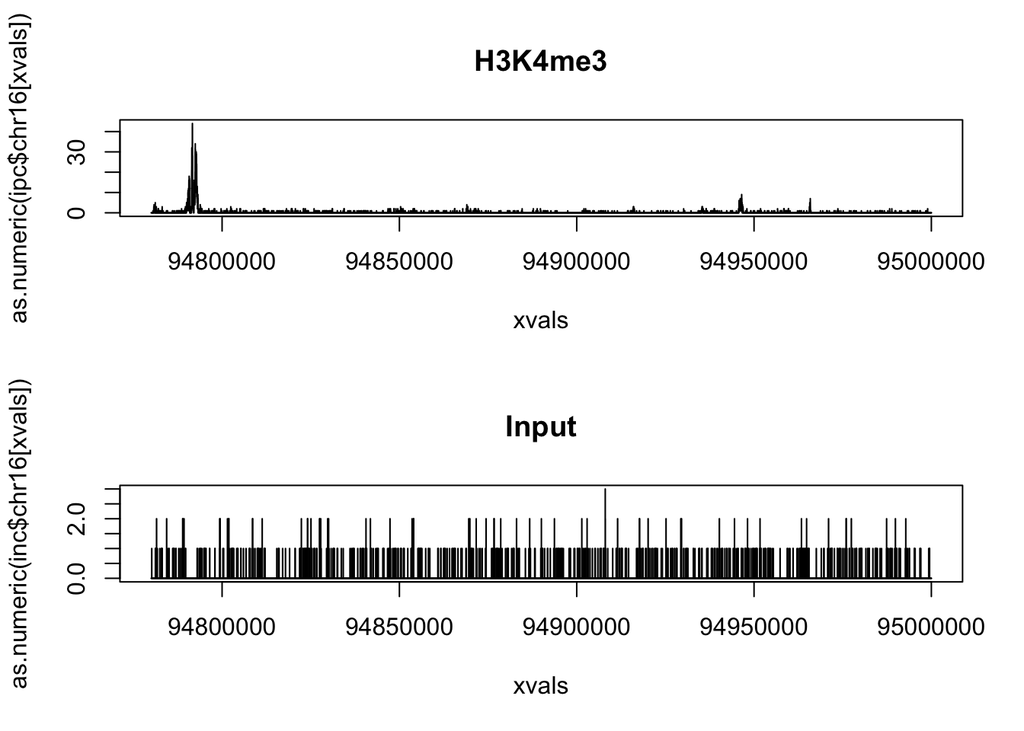

```r
ipg <- GRanges(ip$V1, IRanges(ip$V2,ip$V3), strand=ip$V6)
ing <- GRanges(iN$V1, IRanges(iN$V2,iN$V3), strand=iN$V6)

ipc <- coverage(ipg)
inc <- coverage(ing)

par(mfrow=c(2,1))
xvals <- 94780000:95000000
plot(xvals, as.numeric(ipc$chr16[xvals]), type="l", main="H3K4me3")
plot(xvals, as.numeric(inc$chr16[xvals]), type="l", main="Input")
```

### Exercise 2. Look through the results from `bayespeak()` (in the `bpo` object), try and make some plots of read densities relative to called peaks, (perhaps) similar to those above but ideally with the read density *by strand* to be able to convince yourself that the HMM is calling peaks only when reads are observed from both strands.

## Robustness example

### Exercise 3. Simulate some data with a linear relationships (e.g., n=100 with X uniformly distribution between 0 and 1 and Y = aX + b where b is normally distributed, centred at 0 with some variance). Randomly pick a portion of points and introduce outliers into them. Fit a linear model and a robust linear model (either through a software package or manually computed) and compare the fits.